# FinancIA

En este notebook, presentaremos un prototipo de detector de sentimientos de noticias, una aplicación emocionante de la inteligencia artificial en el campo financiero. Nuestro objetivo principal es realizar un análisis exploratorio de texto utilizando técnicas de procesamiento del lenguaje natural (NLP, por sus siglas en inglés) para clasificar las noticias según su tono emocional.

En el prototipo del detector de sentimientos de noticias, se utilizan varias bibliotecas para diferentes tareas. Aquí hay un resumen de las bibliotecas utilizadas:

- os: Esta biblioteca proporciona funciones para interactuar con el sistema operativo, como la manipulación de rutas de archivos y directorios.
- pathlib: Esta biblioteca proporciona una interfaz orientada a objetos para trabajar con rutas de archivos y directorios de manera más intuitiva.
- matplotlib: Esta biblioteca se utiliza para visualizar datos y generar gráficos, como histogramas y gráficos de barras. En el prototipo, se utiliza para visualizar los resultados del análisis exploratorio de texto.
- pandas: Esta biblioteca se utiliza para el análisis y manipulación de datos en forma de tablas. En el prototipo, se utiliza para cargar y manipular los datos de las noticias.
- spacy: Esta biblioteca es una poderosa herramienta de procesamiento de lenguaje natural (NLP). En el prototipo, se utiliza para acceder a las palabras vacías (stop words) en español, que son palabras comunes pero no aportan información significativa para el análisis de sentimientos.
- wordcloud: Esta biblioteca se utiliza para generar nubes de palabras, que son visualizaciones que muestran las palabras más frecuentes en un texto. En el prototipo, se utiliza para visualizar las palabras más frecuentes en las noticias recopiladas.

```python
# Importamos las librerías necesarias
import os
from pathlib import Path
from matplotlib import pyplot as plt
import pandas as pd
from spacy.lang.es.stop_words import STOP_WORDS as es_stopwords
from wordcloud import WordCloud
```

```python
# Dataset y configuraciones del los proyectos
# Configigurations
path = Path().cwd().parent/"Dataset"
```

Estas son funciones que usan para hacer análsis de texto, lo importante es entender que lo usamos para plotear nube de palabras

```python
# Funciones usadas para plotear los datos
def plots_world_cloud(df, title, figsize=(10, 10)):
    """This function is used to plot the world cloud"""
    text = " ".join(df)
    plt.figure(figsize=figsize)
    wordcloud = WordCloud(background_color="white", stopwords=es_stopwords).generate(text)
    plt.imshow(wordcloud, interpolation='bilinear')
    plt.axis("off")
    plt.title(title)
    plt.show()
```

El tamaño del texto es crucial al seleccionar modelos adecuados. La longitud promedio y la variabilidad determinan si se requieren enfoques basados en transformadores y el impacto en los recursos computacionales. Esto optimiza el rendimiento del análisis de sentimientos y el procesamiento de texto.

```python
# Importamos los datasets y los usamos para explorar los datos
df_train = pd.read_csv(path/"train.csv")
df_test = pd.read_csv(path/"test.csv")

df_train["len"] = df_train.text.apply(len)
df_train["tag"] = "train"
df_test["len"] = df_test.text.apply(len)
df_test["tag"] = "test"
df_train = pd.concat([df_train, df_test], axis=0)
```

```python
#
df_train.head()
```

|  | id | text | target | target_sentiment | companies_sentiment | consumers_sentiment | len | tag |
| --- | --- | --- | --- | --- | --- | --- | --- | --- |
| 0 | 69737 | Renfe afronta mañana un nuevo día de paros par... | Renfe | negative | negative | negative | 71 | train |
| 1 | 71795 | Presupuesto populista con cimientos frágiles | Presupuesto populista | negative | negative | negative | 44 | train |
| 2 | 77984 | Biden no cree que la OPEP+ vaya a ayudar con l... | OPEP+ | negative | negative | negative | 69 | train |
| 3 | 82648 | La deuda de las familias cae en 25.000 millone... | deuda de las familias | positive | positive | positive | 91 | train |
| 4 | 97337 | Bestinver: no hay "momento más inoportuno" par... | Bestinver | negative | negative | negative | 57 | train |

|

**Imagen 1: Primeras filas del dastaset**

|

# Limpiamos el texto.

Veamos las primeras cinco filas de los datos, podemos ver lo siguientes valores.

- id: Identificador único de la noticia
- text: Texto o titulo de la noticia
- target:
- tag : Esta etiqueta se creo para separar la noticia de testeo y entrenamiento
- len: Tamaño del texto
- Consumer_sentiment: Este es el sentimiento, que el titular de la noticia genera para el consumidor. Puede dividirse en Negativo, Neutro o Positivo
- Companies_sentimient: Este es setimiento, que el titular de la noticia genera en la compañia. Puede dividirse en Negativo, Neutro o positivo
- target_sentimient: sentimiento general asociado con la noticia

### Variable objectivo.

El objetivo del modelo es predecir el sentimiento para las variables "target", "companies" y "consumer", donde cada una de ellas se divide en tres categorías: positiva, negativa y neutral. Esto implica que el vector objetivo será de nueve componentes, ya que cada variable tiene tres categorías posibles. El problema de clasificación se convierte en un problema de múltiples etiquetas, lo que significa que una fila en el conjunto de datos puede pertenecer a varias categorías a la vez. El objetivo del modelo será predecir las etiquetas correspondientes a cada una de las nueve combinaciones posibles de sentimientos para las tres variables.

```python
pd.get_dummies(df_train[["target_sentiment", "companies_sentiment", "consumers_sentiment"]], columns=["target_sentiment", "companies_sentiment", "consumers_sentiment"]).iloc[0].astype(int)
```

[output not shown]

|

**Imagen 2: Vector de caracteristica.**

|

Entiendo. Según la imagen del vector de características, se espera que la red neuronal produzca valores cercanos a 1 para indicar la asociación del texto con una determinada característica o categoría de sentimiento. Esto implica que cuanto más cercano esté el valor a 1, mayor será la probabilidad de que el texto esté relacionado con esa característica específica.

En un problema de clasificación de múltiples etiquetas, donde se busca predecir varias categorías simultáneamente, los valores del vector de características pueden interpretarse como la probabilidad de pertenencia a cada una de las categorías. Por lo tanto, un valor cercano a 1 indica una alta probabilidad de que el texto pertenezca a una categoría en particular.

Es importante tener en cuenta que la interpretación exacta de los valores depende del enfoque y la configuración específica del modelo utilizado. Algunos modelos pueden generar probabilidades directamente a través de una función de activación de salida, como la función sigmoide, mientras que otros pueden producir valores continuos que luego se convierten en probabilidades utilizando un umbral determinado.

En resumen, se espera que la red neuronal produzca valores cercanos a 1 en el vector de características para indicar una mayor asociación con una característica específica o categoría de sentimiento en un problema de clasificación de múltiples etiquetas. Estos valores pueden interpretarse como probabilidades de pertenencia a cada categoría.

# Análisis exploratorio

#### Varaiable target_sentiment

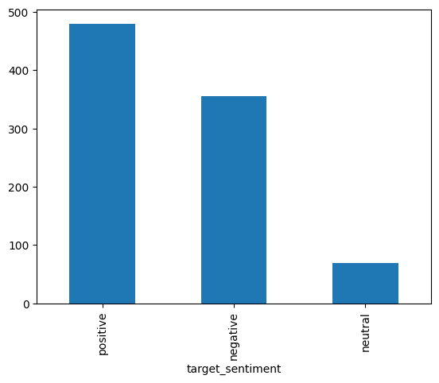

```python
df_train.target_sentiment.value_counts().plot(kind="bar")
```

|

**Imagen 3: Frecuencia de las etiquetas para target_sentimet**

|

La imagen 3 anterior muestra que el dataset está desbalanceado, especialmente en la variable "target_sentiment" donde se observa una mayor cantidad de registros con etiquetas positivas en comparación con las etiquetas negativas y neutrales. El desbalance de clases puede tener un impacto en el rendimiento y la capacidad de generalización de los modelos de aprendizaje automático

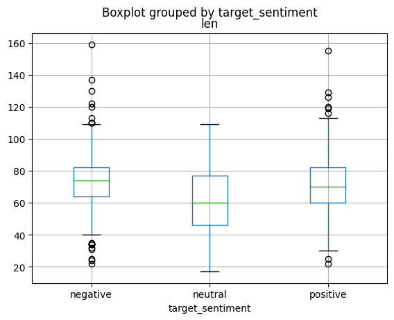

```python
df_train.boxplot(column="len", by="target_sentiment")
```

|

**Imagen 4: Boxplot del tamaño del texto por etiqueta target_sentimet**

|

Basados en la imagen 4, el tamaño de las oraciones también es un aspecto importante a considerar en el análisis. Según los datos proporcionados, se observa que el tamaño máximo de las oraciones es de 160 caracteres. Esto puede ser útil para determinar la longitud máxima de secuencia que se puede utilizar al entrenar los modelos.

Además, se menciona que los encabezados con sentimiento neutral tienden a ser más cortos en comparación con los encabezados con sentimientos positivos. Esta información es relevante, ya que la longitud de las oraciones puede influir en la forma en que se expresan los sentimientos y en cómo se relacionan con las características específicas del texto.

En resumen, al analizar el tamaño de las oraciones en el conjunto de datos y considerar las características relacionadas con la variable "target_sentiment", es posible tener una comprensión más completa de los datos y tomar decisiones informadas en el desarrollo de modelos de análisis de sentimientos.

```python
df_train.groupby("target_sentiment").len.describe()
```

| target_sentiment | count | mean | std | min | 25% | 50% | 75% | max |
| --- | --- | --- | --- | --- | --- | --- | --- | --- |
| negative | 356.0 | 72.870787 | 17.779404 | 22.0 | 63.75 | 74.0 | 82.0 | 159.0 |
| neutral | 69.0 | 61.797101 | 21.466513 | 17.0 | 46.00 | 60.0 | 77.0 | 109.0 |
| positive | 480.0 | 71.352083 | 17.458779 | 22.0 | 60.00 | 70.0 | 82.0 | 155.0 |

|

**Imagen 3: Estadisticas descriptivas target_sentimet**

|

Dado que existe una variabilidad en la longitud de los textos, es posible aplicar técnicas de padding para estandarizar el tamaño y asegurarse de que todos los textos tengan la misma longitud. El padding implica agregar tokens especiales (como ceros) al inicio o final de los textos más cortos para igualar el tamaño de los textos más largos. Esto es especialmente útil cuando se trabaja con modelos basados en transformadores, ya que estos modelos generalmente requieren que todas las secuencias de entrada tengan la misma longitud.

Aplicar padding garantiza que el modelo pueda procesar todos los textos de manera uniforme y mantener la coherencia en la estructura de entrada. Además, esto permite aprovechar al máximo el poder de los modelos de lenguaje, que están diseñados para capturar patrones y relaciones en datos secuenciales.

#### variable companies_sentiment

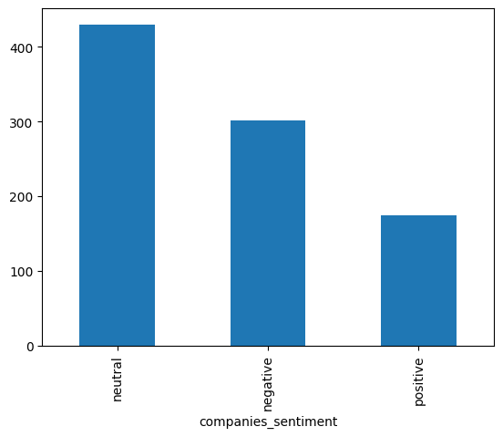

```python
df_train.companies_sentiment.value_counts().plot(kind="bar")
```

|

**Imagen 4: Frecuencia de las etiquetas para companies_sentiment**

|

```python
df_train.groupby("companies_sentiment").len.describe()
```

| companies_sentiment | count | mean | std | min | 25% | 50% | 75% | max |
| --- | --- | --- | --- | --- | --- | --- | --- | --- |
| negative | 301.0 | 72.269103 | 18.411699 | 22.0 | 61.0 | 71.0 | 83.00 | 159.0 |
| neutral | 430.0 | 70.395349 | 18.389644 | 17.0 | 59.0 | 71.5 | 81.00 | 137.0 |
| positive | 174.0 | 71.448276 | 16.873044 | 22.0 | 60.0 | 72.0 | 82.75 | 120.0 |

|

**Imagen 5: Estadisticas descriptivas companies_sentiment**

|

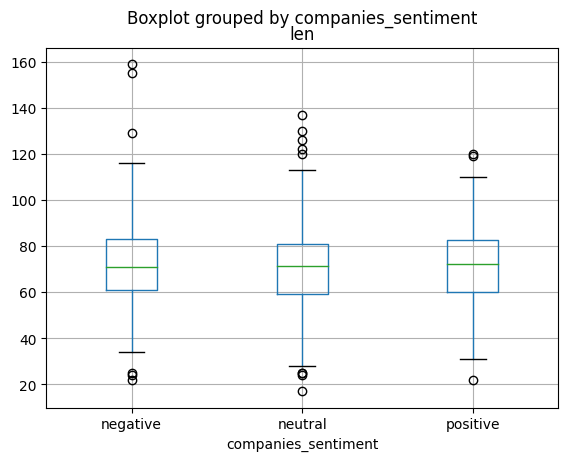

```python
df_train.boxplot(column="len", by="companies_sentiment")
```

|

**Imagen 6: Boxplot del tamaño del texto por etiqueta companies_sentiment**

|

#### consumers_sentiment

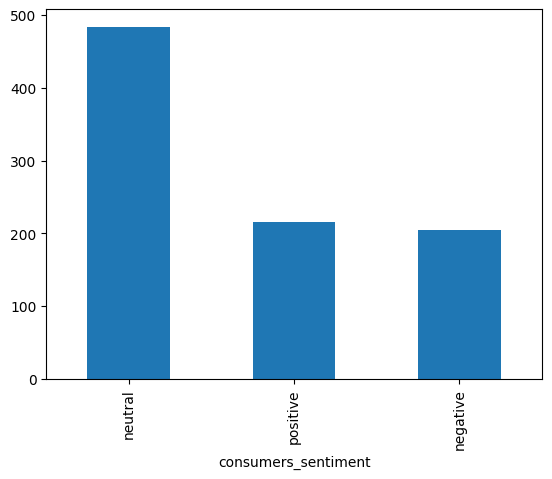

```python
df_train.consumers_sentiment.value_counts().plot(kind="bar")
```

|

**Imagen 7: Frecuencia de las etiquetas para consumers_sentiment**

|

En este caso tambien se observa como la clase neutral es la que tiene más registros. La positiva y negativa, son muy parecidas

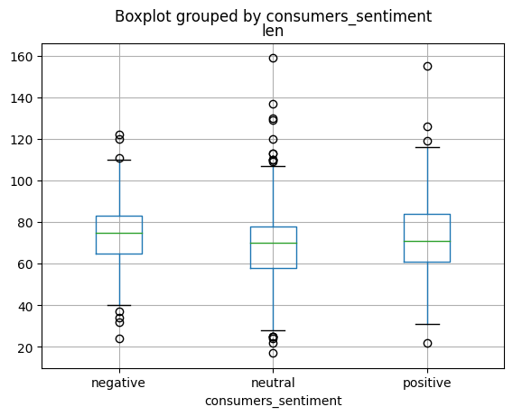

```python
df_train.boxplot(column="len", by="consumers_sentiment")
```

|

**Imagen 8: Boxplot del tamaño del texto por etiqueta consumers_sentiment**

|

#### Conclusiones

En conclusión, al analizar los datos, se pueden destacar los siguientes puntos:

- Desbalance de datos: Existe un desbalance en las etiquetas de la variable "target_sentiment", con una mayor cantidad de registros etiquetados como positivos en comparación con las etiquetas negativas y neutrales. Este desbalance puede requerir técnicas de manejo de clases desbalanceadas durante el entrenamiento del modelo.
- Tamaño de los datos: El tamaño de los textos en el conjunto de datos es relativamente pequeño, con una longitud máxima de 160 caracteres. Esto es útil para determinar la longitud máxima de secuencia que se puede utilizar en los modelos de análisis de sentimientos.
- Análisis de palabras: Se puede realizar un análisis exploratorio para identificar las palabras más comúnmente utilizadas en el texto y examinar las características asociadas con cada etiqueta de sentimiento.
- Padding: Dado que existe variabilidad en la longitud de los textos, se puede aplicar padding para estandarizar el tamaño y asegurarse de que todos los textos tengan la misma longitud. Esto facilita el procesamiento y análisis uniforme de los textos en el modelo de análisis de sentimientos.

## World Cloud

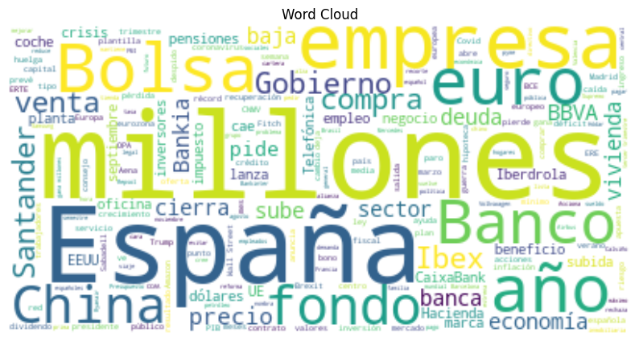

```python
plots_world_cloud(df_train.text, "Word Cloud")
```

|

|

### Target Sentiment

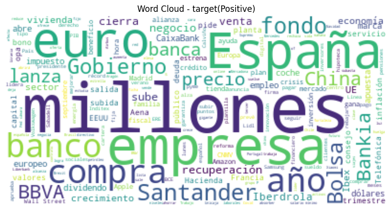

```python
plots_world_cloud(df_train[df_train.target_sentiment == "positive"].text, "Word Cloud - target(Positive)")
```

|

**Imagen 10: World Cloud Target Sentiment Positive**

|

[figure not shown]

```python
plots_world_cloud(df_train[df_train.target_sentiment == "neutral"].text, "Word Cloud - target(Neutral)")
```

|

**Imagen 11: World Cloud Target Sentiment Neutra**

|

### Companies Sentiment

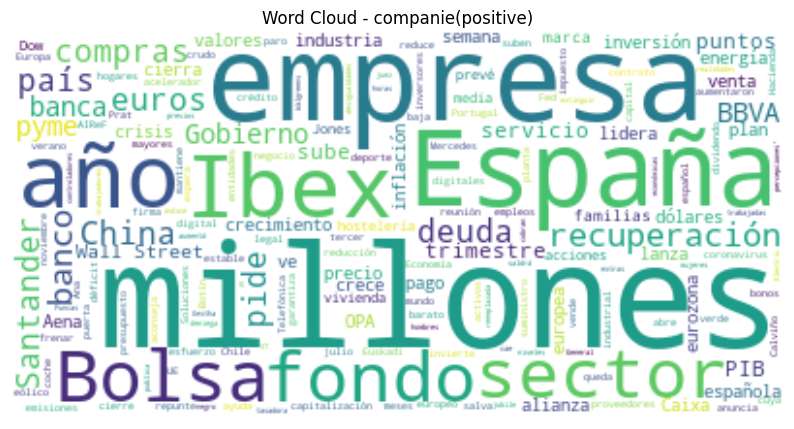

```python
plots_world_cloud(df_train[df_train.companies_sentiment == "positive"].text, "Word Cloud - companie(positive)")
```

|

|

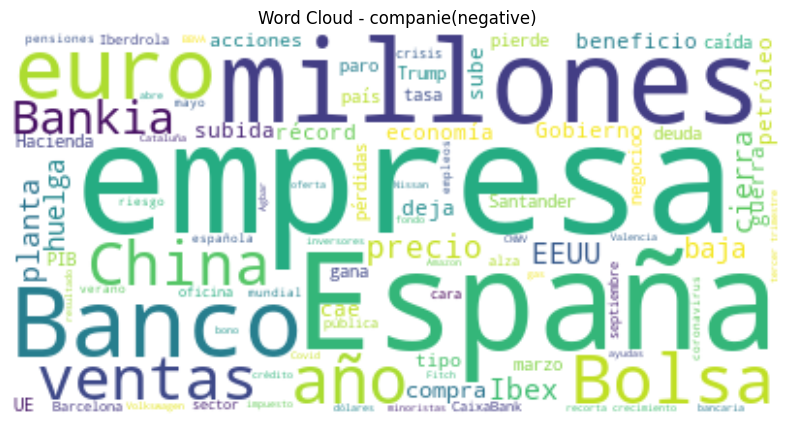

```python
plots_world_cloud(df_train[df_train.companies_sentiment == "negative"].text, "Word Cloud - companie(negative)")
```

|

|

### Consumer sentiment

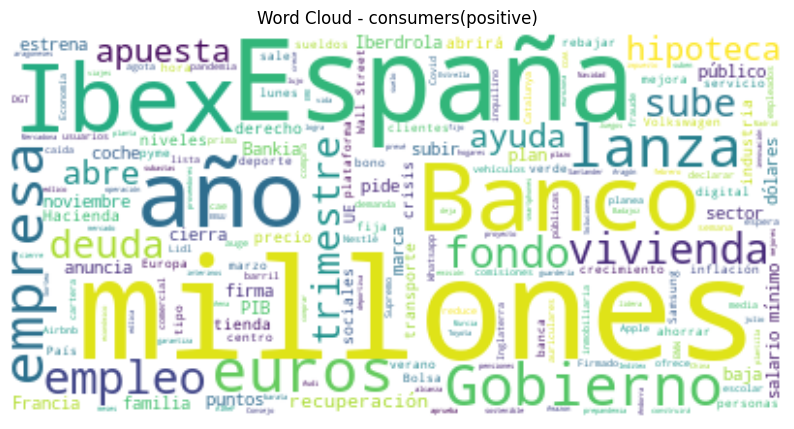

```python
plots_world_cloud(df_train[df_train.consumers_sentiment == "positive"].text, "Word Cloud - consumers(positive)")
```

|

|

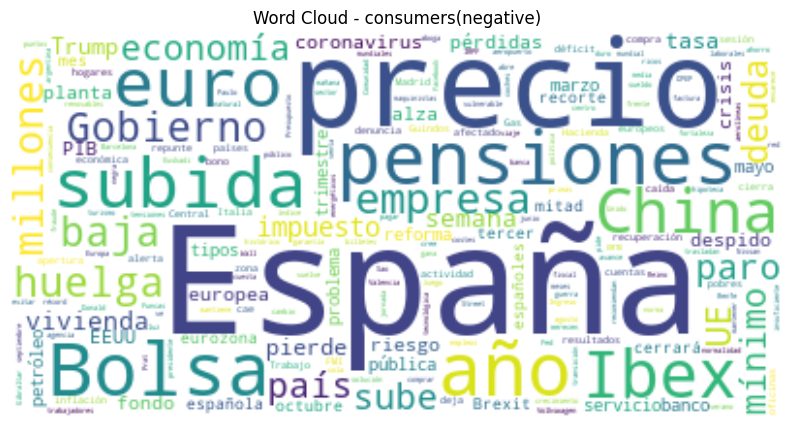

```python
plots_world_cloud(df_train[df_train.consumers_sentiment == "negative"].text, "Word Cloud - consumers(negative)")
```

|

|

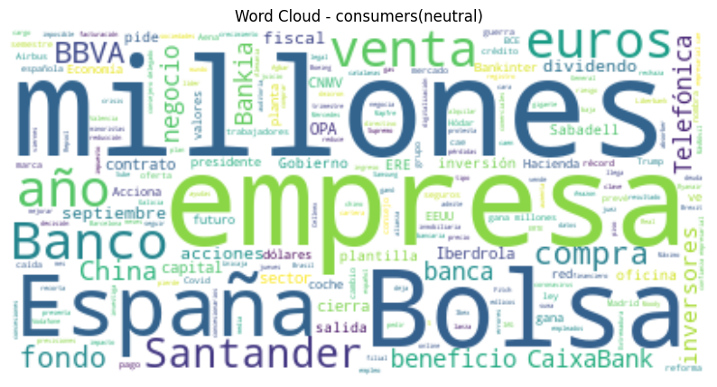

```python
plots_world_cloud(df_train[df_train.consumers_sentiment == "neutral"].text, "Word Cloud - consumers(neutral)")
```

|

|

### Conclusiones

Además de los puntos mencionados anteriormente, hay algunas observaciones adicionales sobre el contexto de las noticias: